# W3cubDocs

/Matplotlib 3.5

# matplotlib.colors.ListedColormap

**class*matplotlib.colors.ListedColormap(*colors*, *name='from_list'*, *N=None*)[[source]](https://github.com/matplotlib/matplotlib/blob/v3.5.1/lib/matplotlib/colors.py#L1012-L1104)**

Bases: `matplotlib.colors.Colormap`

Colormap object generated from a list of colors.

This may be most useful when indexing directly into a colormap, but it can also be used to generate special colormaps for ordinary mapping.

**Parameters**

**colors**list, array**

List of Matplotlib color specifications, or an equivalent Nx3 or Nx4 floating point array (*N* rgb or rgba values).

**name**str, optional**

String to identify the colormap.

**N**int, optional**

Number of entries in the map. The default is *None*, in which case there is one colormap entry for each element in the list of colors. If

```
N < len(colors)
```

the list will be truncated at *N*. If

```
N > len(colors)
```

the list will be extended by repetition.

**Parameters**

**name**str**

The name of the colormap.

**N**int**

The number of rgb quantization levels.

**reversed(*name=None*)[[source]](https://github.com/matplotlib/matplotlib/blob/v3.5.1/lib/matplotlib/colors.py#L1080-L1104)**

Return a reversed instance of the Colormap.

**Parameters**

**name**str, optional**

The name for the reversed colormap. If it's None the name will be the name of the parent colormap + "_r".

**Returns**

**ListedColormap**

A reversed instance of the colormap.

## Examples using `matplotlib.colors.ListedColormap`

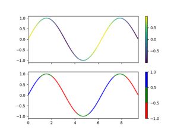

[Multicolored lines](https://matplotlib.org/3.5.1/gallery/lines_bars_and_markers/multicolored_line.html#sphx-glr-gallery-lines-bars-and-markers-multicolored-line-py)

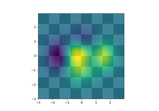

[Layer Images](https://matplotlib.org/3.5.1/gallery/images_contours_and_fields/layer_images.html#sphx-glr-gallery-images-contours-and-fields-layer-images-py)

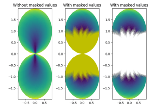

[QuadMesh Demo](https://matplotlib.org/3.5.1/gallery/images_contours_and_fields/quadmesh_demo.html#sphx-glr-gallery-images-contours-and-fields-quadmesh-demo-py)

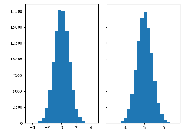

[Histograms](https://matplotlib.org/3.5.1/gallery/statistics/hist.html#sphx-glr-gallery-statistics-hist-py)

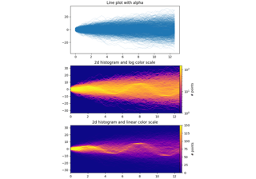

[Time Series Histogram](https://matplotlib.org/3.5.1/gallery/statistics/time_series_histogram.html#sphx-glr-gallery-statistics-time-series-histogram-py)

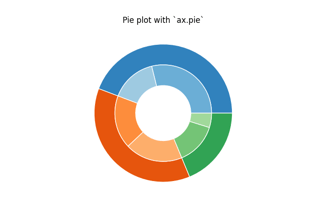

[Nested pie charts](https://matplotlib.org/3.5.1/gallery/pie_and_polar_charts/nested_pie.html#sphx-glr-gallery-pie-and-polar-charts-nested-pie-py)

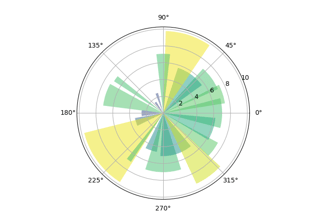

[Bar chart on polar axis](https://matplotlib.org/3.5.1/gallery/pie_and_polar_charts/polar_bar.html#sphx-glr-gallery-pie-and-polar-charts-polar-bar-py)

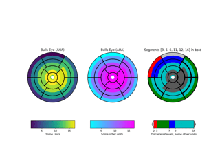

[Left ventricle bullseye](https://matplotlib.org/3.5.1/gallery/specialty_plots/leftventricle_bulleye.html#sphx-glr-gallery-specialty-plots-leftventricle-bulleye-py)

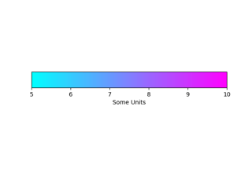

[Customized Colorbars Tutorial](https://matplotlib.org/3.5.1/tutorials/colors/colorbar_only.html#sphx-glr-tutorials-colors-colorbar-only-py)

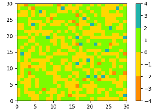

[Creating Colormaps in Matplotlib](https://matplotlib.org/3.5.1/tutorials/colors/colormap-manipulation.html#sphx-glr-tutorials-colors-colormap-manipulation-py)

© 2012–2021 Matplotlib Development Team. All rights reserved.  
Licensed under the Matplotlib License Agreement.  
https://matplotlib.org/3.5.1/api/_as_gen/matplotlib.colors.ListedColormap.html